# exploratory analysis of deepmut variants

# Exploratory analysis

Goals - Identify the best threshold to remove noise; improve quantitative predictions from ML - plotting distributions

## Preliminary setup

```r
library(tidyverse, quietly = TRUE)
library(magrittr) # for special Tee pipe operator %T>% (Error check, unique WT before calc)
library(patchwork) # for combining plots

# import functions
source("functions/0.data_processing.R")
source("functions/1.plotting.R")
source("functions/2.contribution_table.R")

# locate the data
base_path <- "enrichment_data/theoAptzepPCR_lokya/"
# file_path <- str_c(base_path, "subset.tsv") # for testing
file_path <- str_c(base_path, "DiMSum_Project_variant_data_merge.tsv") # for production

# global variables
expected_variants <- 135000 # (epPCR) from colony counts (source: Lokya)
count_tracker <- tibble(
  threshold = numeric(),
  variants = numeric(),
  input_reads = numeric(),
  filtered_columns = character()) # global variable to track counts at different thresholds
```

## Data cleanup

- Select relevant columns
- Clean up column names
- Calculate enrichment, leak metrics Ref: _Borrowing some code from DiMSum/[split-multiinputs.R](https://github.com/ppreshant/DiMSum/blob/master/scripts/split_multiinputs.R)

```r
data <- read_and_cleanup_data(file_path)
```

```
1 => A single wild-type sequence found (Nham_nt == 0); will proceed with relative catalysis/leak calculations
```

```r
cat("Column names: ", paste(colnames(data), collapse = ", "), "\n")
```

```
Column names:  nt_seq, Nham_nt, Input_count, Selection_count, Selection_50_count, Selection_75_count, Leak_count, sequence_length, input_freq, selection_freq, selection_50_freq, selection_75_freq, leak_freq, catalysis_score, leak_score, relative_catalysis, relative_leak, net_catalysis, catalysis_sco…
```

```r
total_variants <- nrow(data)
total_reads <- sum(data$Input_count)

# count_tracker <- count_tracker |>
#   add_row(threshold = 0,
#           variants = total_variants, input_reads = total_reads,
#           filtered_columns = "")

cat("Total variants: ", format(total_variants, big.mark = ","), "\n")
```

```
Total variants:  540,324
```

```r
cat("Total reads: ", format(total_reads, big.mark = ","), "\n")
```

```
Total reads:  72,200,812
```

## Raw visualization

```r
# nham_variant_count_distribution(head(data, 1000)) # top 1,000 data
var_raw <- nham_variant_count_distribution(data) # all data
read_raw <- nham_read_count_distribution(data)
```

Plotting the distribution of reads in the raw data, selection counts, and leak counts. This will help us understand the distribution of reads across different categories.

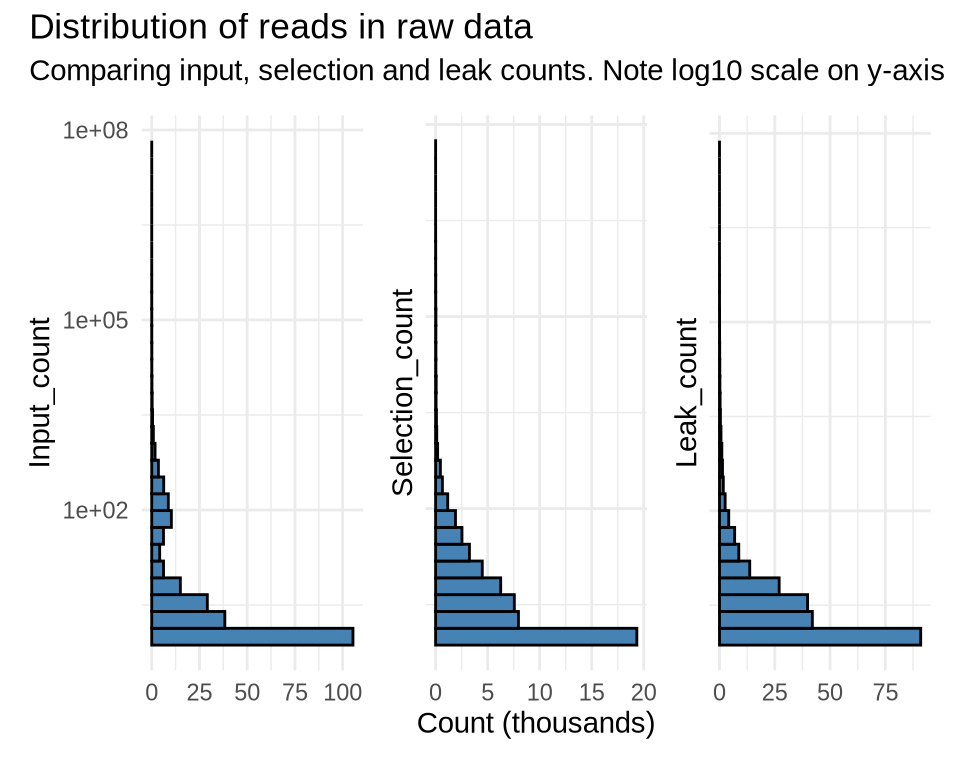

```r
patch_read_dist_multi_columns(data) +
  plot_annotation(title = "Distribution of reads in raw data",
                  subtitle = "Comparing input, selection and leak counts. Note log10 scale on y-axis")
```

Looking at the distribution of reads, we can see that there are a lot of variants with low counts. We want to filter out these low-count variants to reduce noise in our analysis.

# Filtering within Input, Selection, and Leak counts

Table of variant counts and input reads at different thresholds

```r
thresholds <- c(0, 1, 2, 5, 10, 100)
filter_set_25 <- c("Input_count", "Selection_count", "Leak_count")

filter_list_25 <-
  map(thresholds,
    filter_data, df = data, filter_columns = filter_set_25)

count_log_25 <- bind_rows(count_tracker,
  map(filter_list_25, \(x) x$count_tracker) |>
  bind_rows())
```

## Distribution of reads at different thresholds

[output not shown]

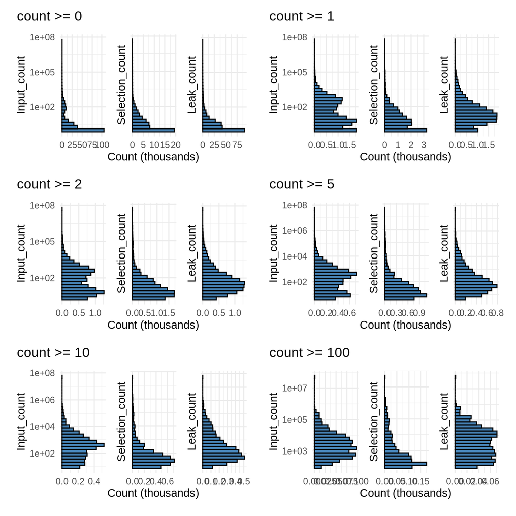

[output not shown]

```r
read_distribution_25 <-
  map2(filter_list_25, thresholds,
    \(x, t) patch_read_dist_multi_columns(x$filtered, title = str_c("count >= ", t))) |>

    map(\(x) wrap_elements(full = x)) |> # freeze titles of each patch
    wrap_plots(ncol = 2, axes = "collect") |>
    plot_annotation(title = "Distribution of reads at different thresholds", subtitle = "Comparing input, selection and leak counts. Note log10 scale on y-axis")

read_distribution_25
```

## Distributions across hamming distance

[output not shown]

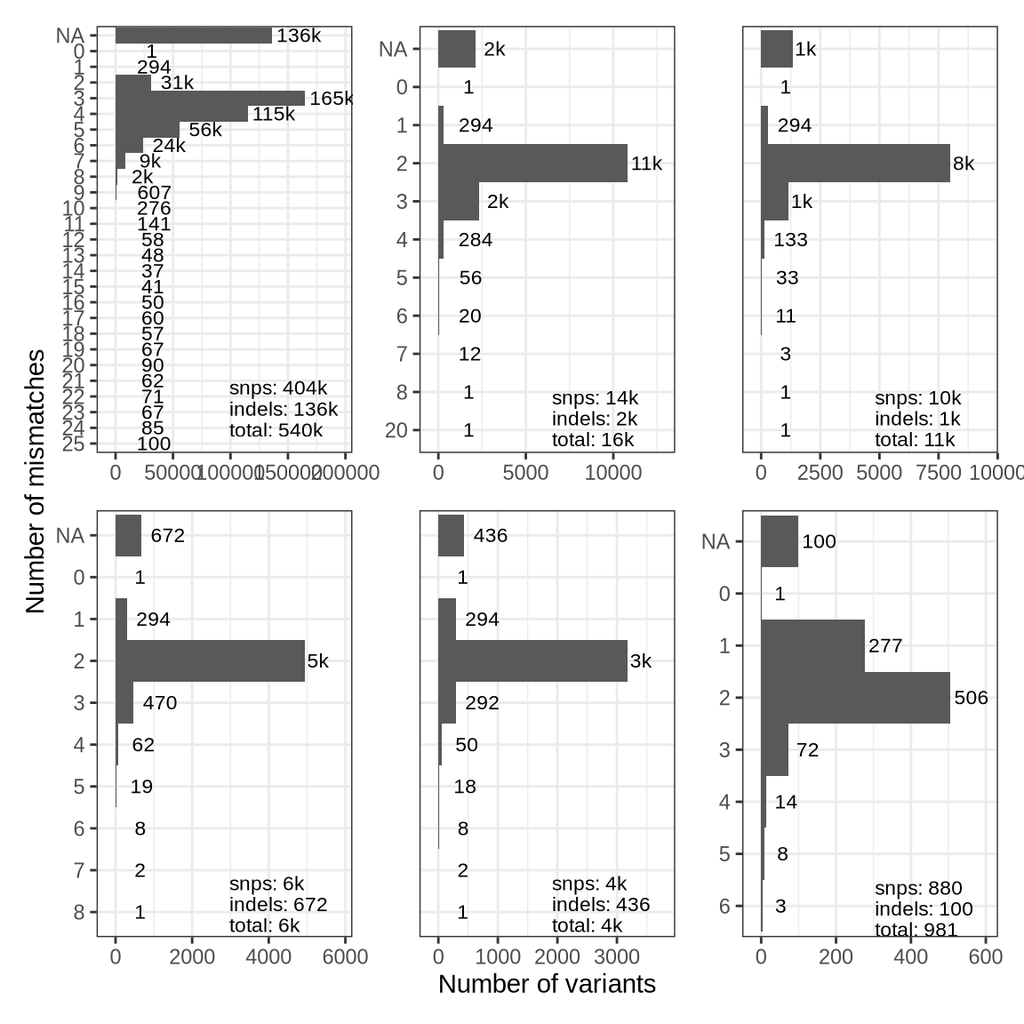

[output not shown]

```r
var_nham_plots_25 <-
  map(filter_list_25,
    \(x) nham_variant_count_distribution(x$filtered)) |>
  patchwork::wrap_plots(axes = "collect") |>
  plot_annotation(title = "Distribution of variants by hamming distance") |>
  print()
```

[output not shown]

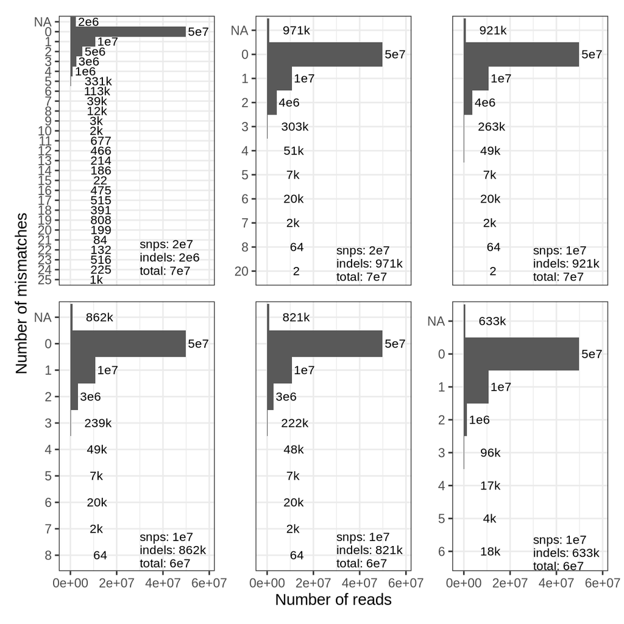

[output not shown]

```r
read_nham_plots_25 <-
  map(filter_list_25,
    \(x) nham_read_count_distribution(x$filtered)) |>
  patchwork::wrap_plots(axes = "collect") |>
  plot_annotation(title = "Distribution of reads by hamming distance") |>
  print()
```

## Variant counts vs expected

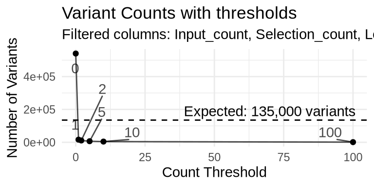

```r
variant_count_by_threshold(count_log_25, filter_set_25)
```

## Track reads by threshold

```r
format_count_log(count_log_25)
```

| Count Threshold | Retained Variants (%) | Retained Reads (%) | Number of Variants | Number of Input Reads |
| --- | --- | --- | --- | --- |
| 0 | 100.00 | 100 | 540,324 | 72,200,812 |
| 1 | 2.96 | 91 | 15,975 | 65,992,019 |
| 2 | 2.03 | 91 | 10,981 | 65,561,416 |
| 5 | 1.20 | 90 | 6,476 | 64,950,644 |
| 10 | 0.79 | 89 | 4,285 | 64,470,317 |
| 100 | 0.18 | 87 | 981 | 62,570,128 |

## Catalysis/leak analysis

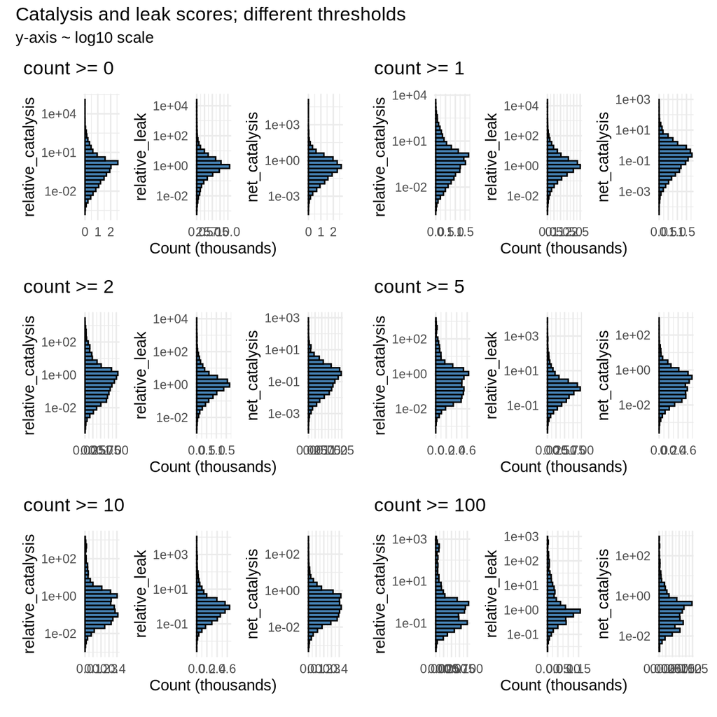

```r
score_columns_25 <- c("relative_catalysis", "relative_leak", "net_catalysis")

catleak_distribution_25 <-
  map2(filter_list_25, thresholds,
    \(x, t)
      patch_read_dist_multi_columns(x$filtered,
        .cols = score_columns_25,
        title = str_c("count >= ", t))) |>

    map(\(x) wrap_elements(full = x)) |> # freeze titles of each patch
    wrap_plots(ncol = 2, axes = "collect")

catleak_distribution_25 +
    plot_annotation(title = "Catalysis and leak scores; different thresholds", subtitle = "y-axis ~ log10 scale") &
    geom_hline(yintercept = 1, color = "red")
```

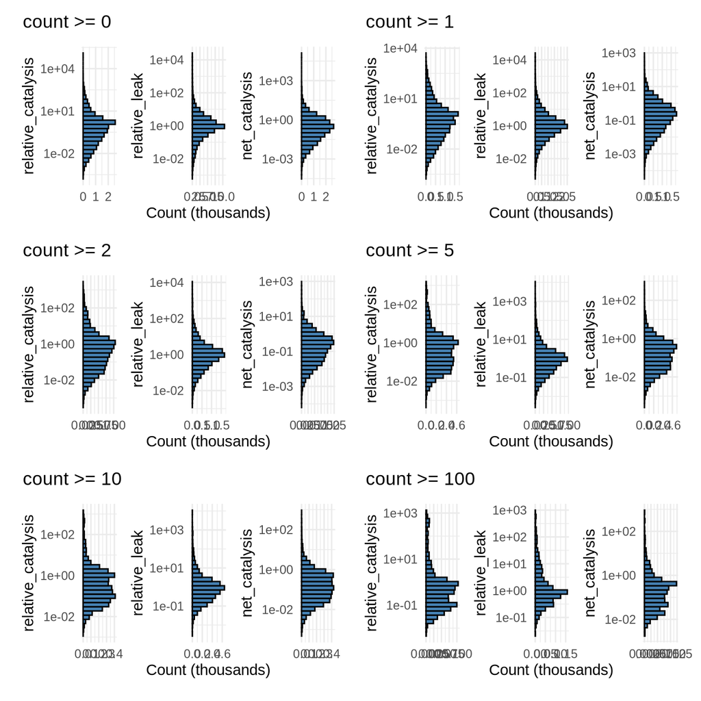

```r
catleak_distribution_25
```

# Filtering within Input and Selection 50 counts

Table of variant counts and input reads at different thresholds

```r
filter_set_50 <- c("Input_count", "Selection_50_count")

filter_list_50 <-
  map(thresholds,
    filter_data, df = data, filter_columns = filter_set_50)

count_log_50 <- bind_rows(count_tracker,
  map(filter_list_50, \(x) x$count_tracker) |>
  bind_rows())
```

## Distribution of reads at different thresholds

[output not shown]

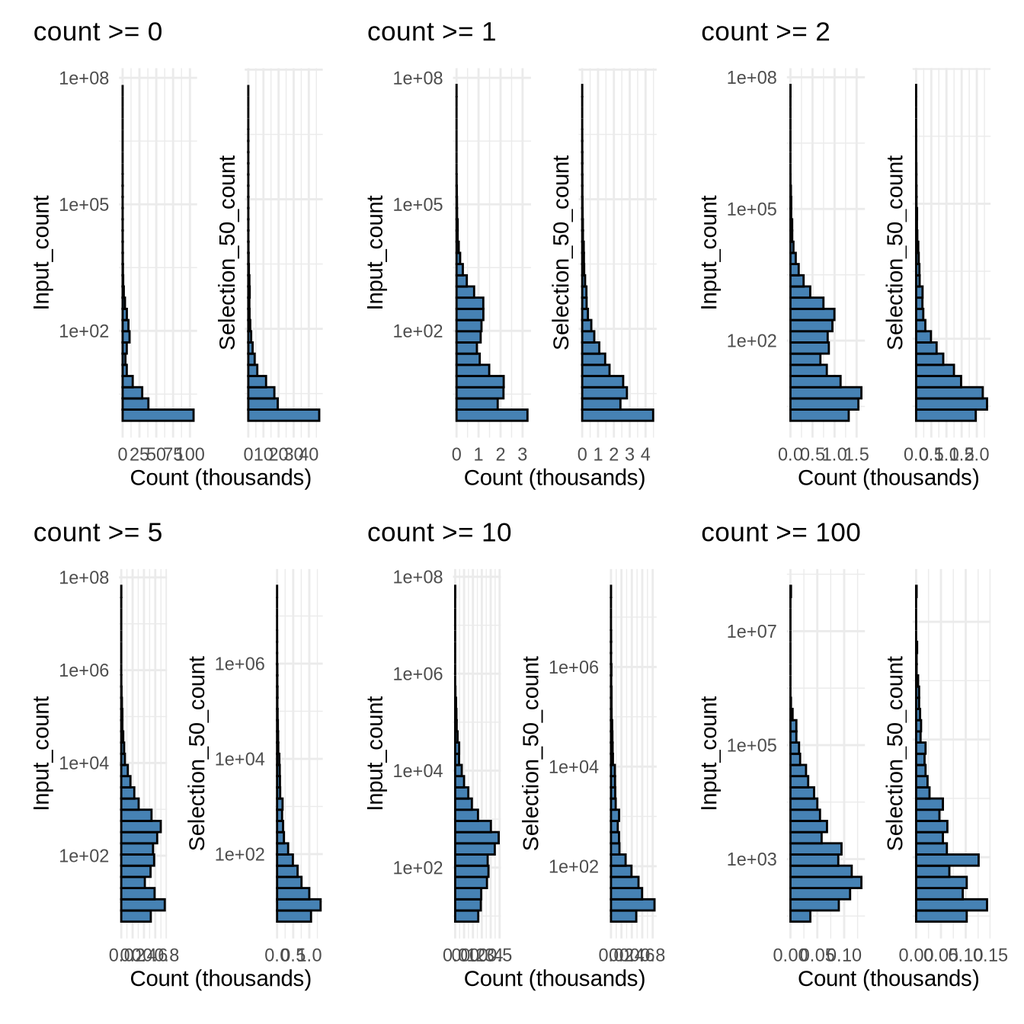

[output not shown]

```r
read_distribution_50 <-
  map2(filter_list_50, thresholds,
    \(x, t)
      patch_read_dist_multi_columns(x$filtered,
        .cols = filter_set_50,
        title = str_c("count >= ", t))) |>

    map(\(x) wrap_elements(full = x)) |> # freeze titles of each patch
    wrap_plots(ncol = 3, axes = "collect") |>
    plot_annotation(title = "Distribution of reads at different thresholds", subtitle = "Comparing input, selection and leak counts. Note log10 scale on y-axis")

read_distribution_50
```

## Distributions across hamming distance

[output not shown]

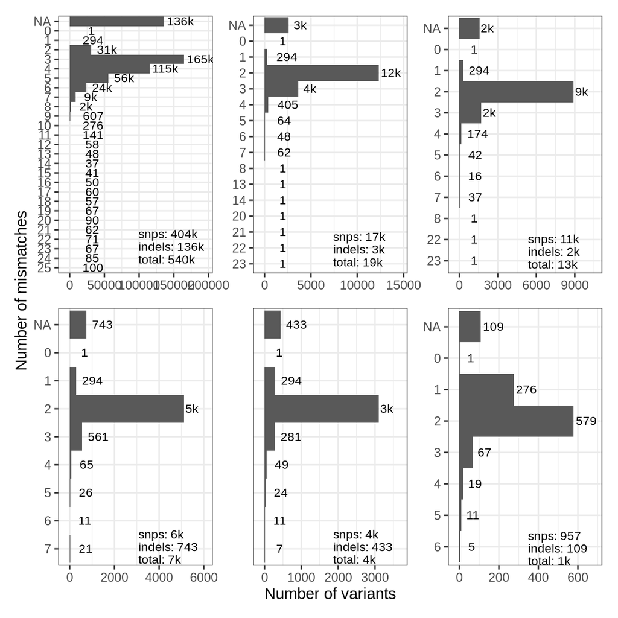

[output not shown]

```r
var_nham_plots_50 <-
  map(filter_list_50,
    \(x) nham_variant_count_distribution(x$filtered)) |>
  patchwork::wrap_plots(axes = "collect") |>
  plot_annotation(title = "Distribution of variants by hamming distance") |>
  print()
```

[output not shown]

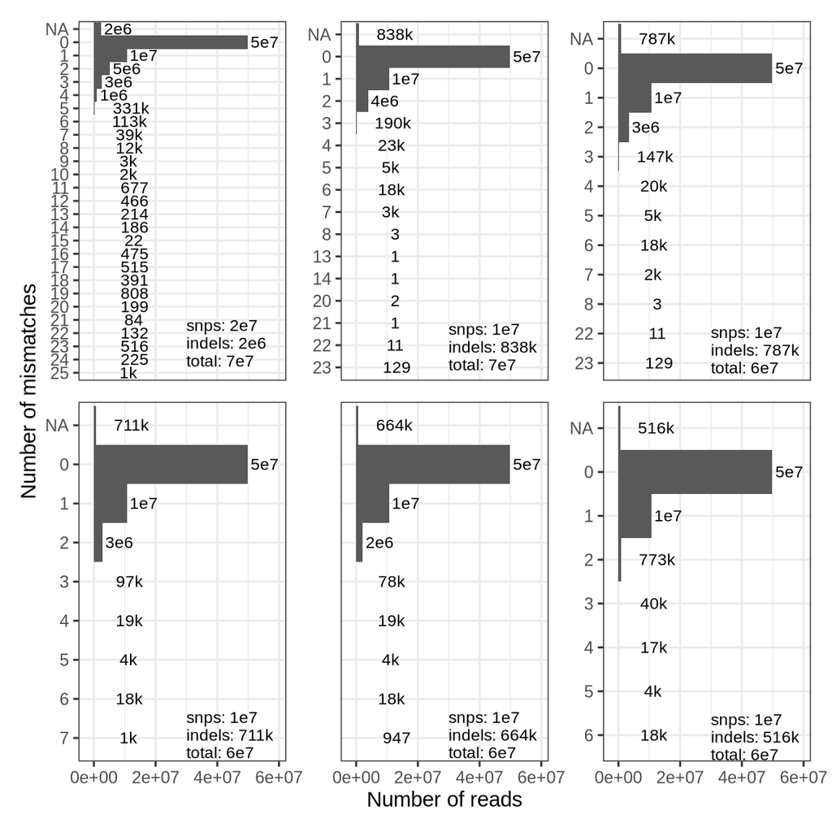

[output not shown]

```r
read_nham_plots_50 <-
  map(filter_list_50  ,
    \(x) nham_read_count_distribution(x$filtered)) |>
  patchwork::wrap_plots(axes = "collect") |>
  plot_annotation(title = "Distribution of reads by hamming distance") |>
  print()
```

## Variant counts vs expected

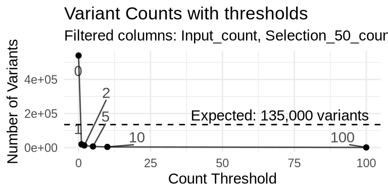

```r
variant_count_by_threshold(count_log_50, filter_set_50)
```

## Track reads by threshold

```r
format_count_log(count_log_50)
```

| Count Threshold | Retained Variants (%) | Retained Reads (%) | Number of Variants | Number of Input Reads |
| --- | --- | --- | --- | --- |
| 0 | 100.00 | 100 | 540,324 | 72,200,812 |
| 1 | 3.60 | 91 | 19,478 | 65,467,193 |
| 2 | 2.36 | 90 | 12,766 | 64,935,364 |
| 5 | 1.27 | 89 | 6,840 | 64,163,098 |
| 10 | 0.78 | 88 | 4,207 | 63,502,816 |
| 100 | 0.20 | 86 | 1,067 | 61,902,934 |

## Catalysis analysis

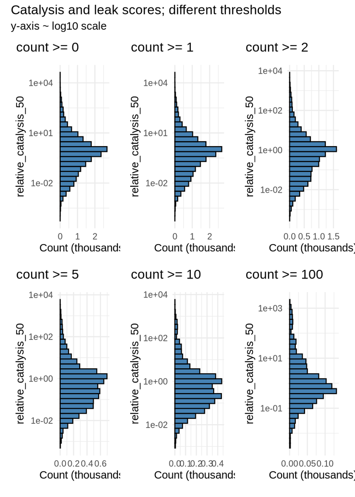

```r
score_columns_50 <- c("relative_catalysis_50")

catleak_distribution_50 <-
  map2(filter_list_50, thresholds,
    \(x, t)
      patch_read_dist_multi_columns(x$filtered,
        .cols = score_columns_50,
        title = str_c("count >= ", t))) |>

    map(\(x) wrap_elements(full = x)) |> # freeze titles of each patch
    wrap_plots(ncol = 3, axes = "collect")

catleak_distribution_50 +
    plot_annotation(title = "Catalysis and leak scores; different thresholds", subtitle = "y-axis ~ log10 scale") &
    geom_hline(yintercept = 1, color = "red")
```

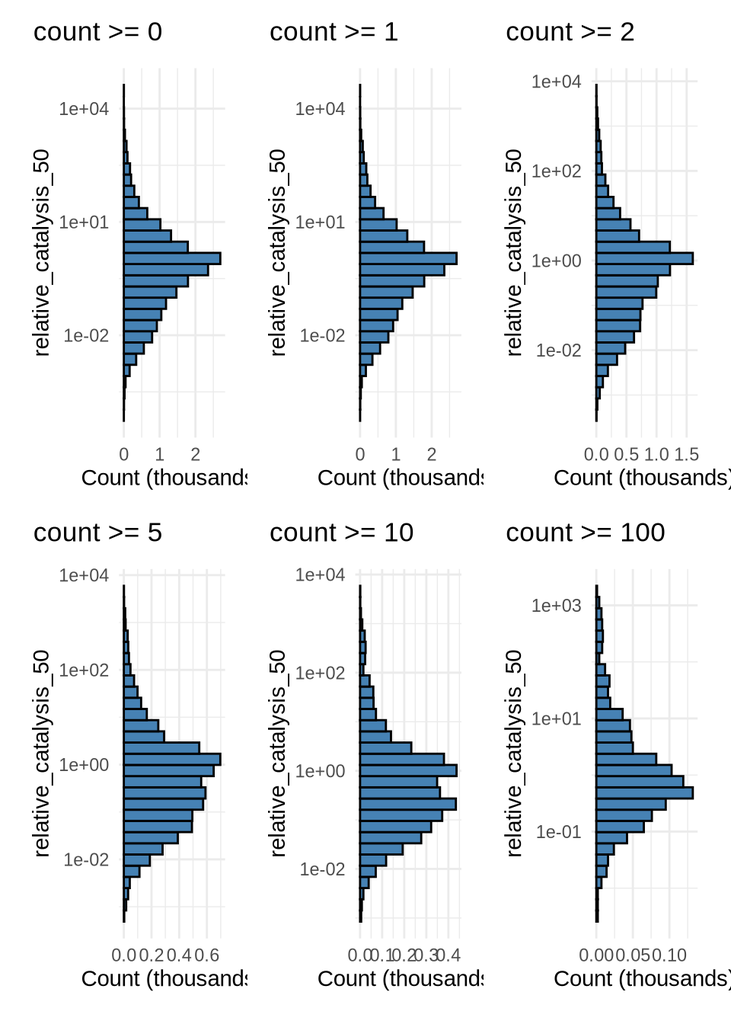

```r
catleak_distribution_50
```

# Filtering within Input and Selection 75 counts

Table of variant counts and input reads at different thresholds

```r
filter_set_75 <- c("Input_count", "Selection_75_count")

filter_list_75 <-
  map(thresholds,
    filter_data, df = data, filter_columns = filter_set_75)

count_log_75 <- bind_rows(count_tracker,
  map(filter_list_75, \(x) x$count_tracker) |>
  bind_rows())
```

## Distribution of reads at different thresholds

[output not shown]

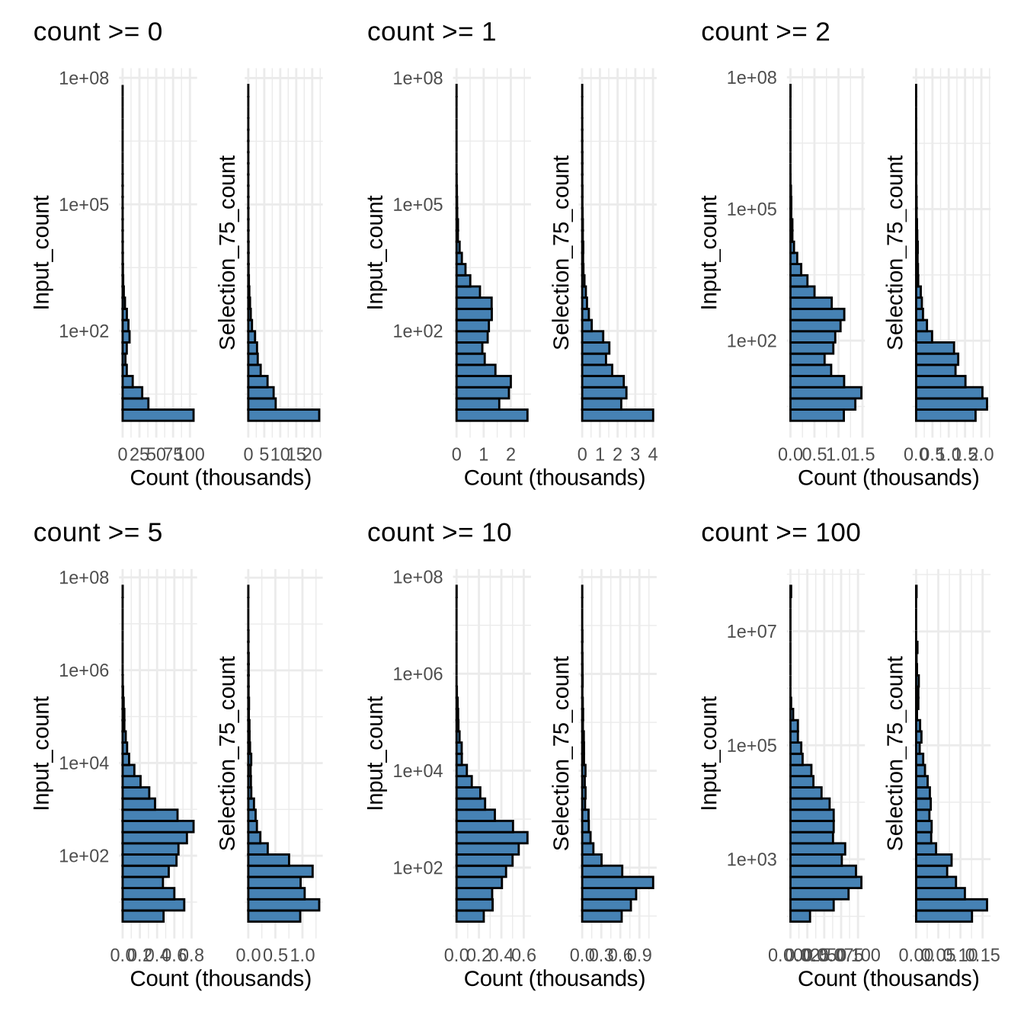

[output not shown]

```r
read_distribution_75 <-
  map2(filter_list_75, thresholds,
    \(x, t)
      patch_read_dist_multi_columns(x$filtered,
        .cols = filter_set_75,
        title = str_c("count >= ", t))) |>

    map(\(x) wrap_elements(full = x)) |> # freeze titles of each patch
    wrap_plots(ncol = 3, axes = "collect") |>
    plot_annotation(title = "Distribution of reads at different thresholds", subtitle = "Comparing input, selection and leak counts. Note log10 scale on y-axis")

read_distribution_75
```

## Distributions across hamming distance

[output not shown]

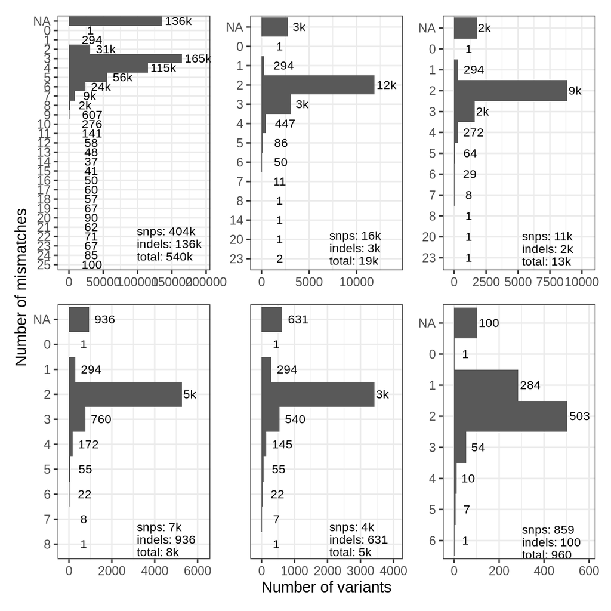

[output not shown]

```r
var_nham_plots_75 <-
  map(filter_list_75,
    \(x) nham_variant_count_distribution(x$filtered)) |>
  patchwork::wrap_plots(axes = "collect") |>
  plot_annotation(title = "Distribution of variants by hamming distance") |>
  print()
```

[output not shown]

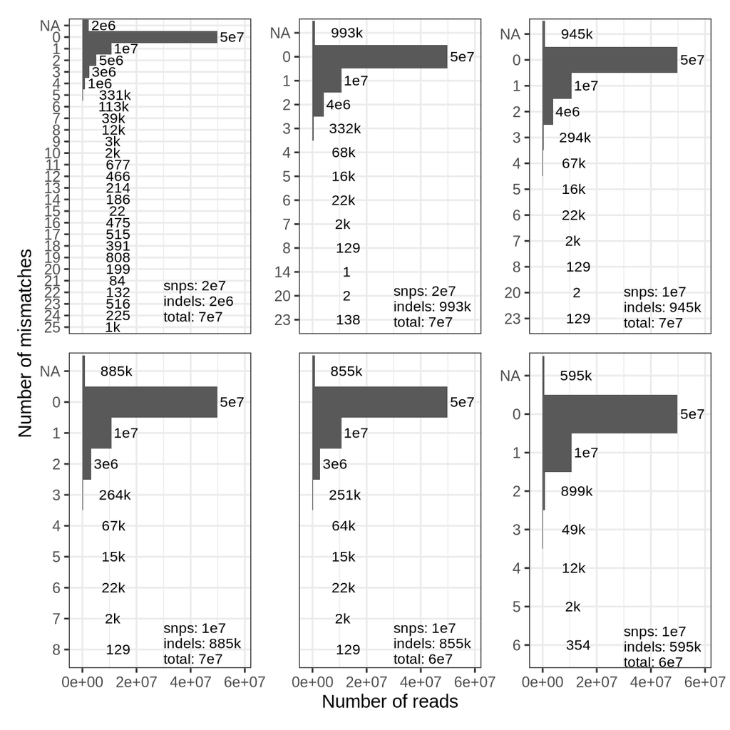

[output not shown]

```r
read_nham_plots_75 <-
  map(filter_list_75,
    \(x) nham_read_count_distribution(x$filtered)) |>
  patchwork::wrap_plots(axes = "collect") |>
  plot_annotation(title = "Distribution of reads by hamming distance") |>
  print()
```

## Variant counts vs expected

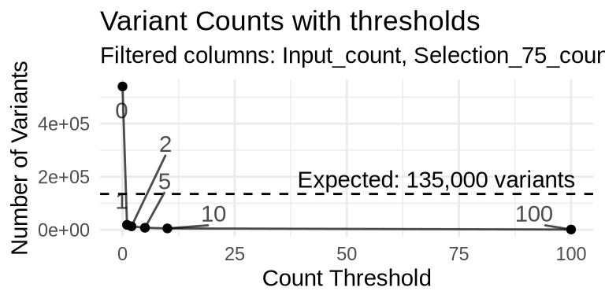

```r
variant_count_by_threshold(count_log_75, filter_set_75)
```

## Track reads by threshold

```r
format_count_log(count_log_75)
```

| Count Threshold | Retained Variants (%) | Retained Reads (%) | Number of Variants | Number of Input Reads |
| --- | --- | --- | --- | --- |
| 0 | 100.00 | 100 | 540,324 | 72,200,812 |
| 1 | 3.45 | 92 | 18,655 | 66,116,161 |
| 2 | 2.39 | 91 | 12,887 | 65,709,164 |
| 5 | 1.39 | 90 | 7,523 | 65,094,880 |
| 10 | 0.95 | 90 | 5,124 | 64,620,207 |
| 100 | 0.18 | 86 | 960 | 62,103,706 |

## Catalysis analysis

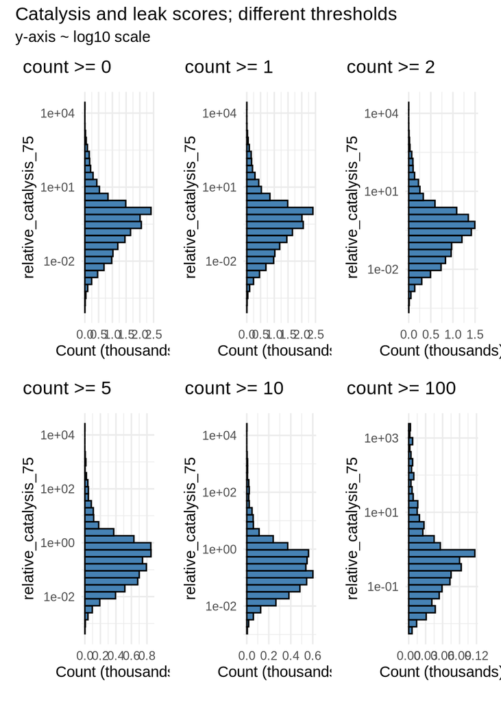

```r
score_columns_75 <- c("relative_catalysis_75")

catleak_distribution_75 <-
  map2(filter_list_75, thresholds,
    \(x, t)
      patch_read_dist_multi_columns(x$filtered,
        .cols = score_columns_75,
        title = str_c("count >= ", t))) |>

    map(\(x) wrap_elements(full = x)) |> # freeze titles of each patch
    wrap_plots(ncol = 3, axes = "collect")

catleak_distribution_75 +
    plot_annotation(title = "Catalysis and leak scores; different thresholds", subtitle = "y-axis ~ log10 scale") &
    geom_hline(yintercept = 1, color = "red")
```

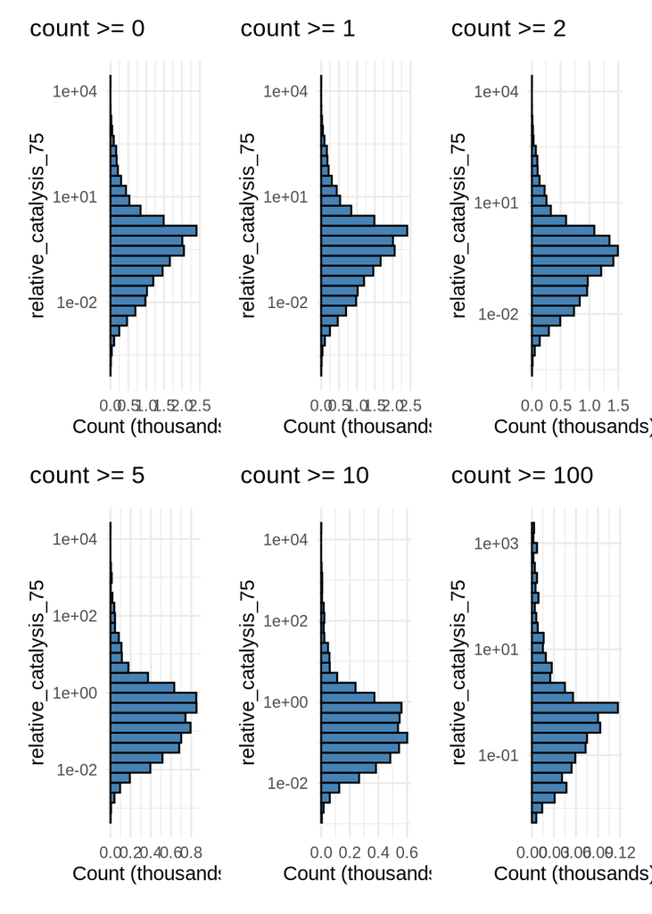

```r
catleak_distribution_75
```

# Indel analysis

## Read count distribution

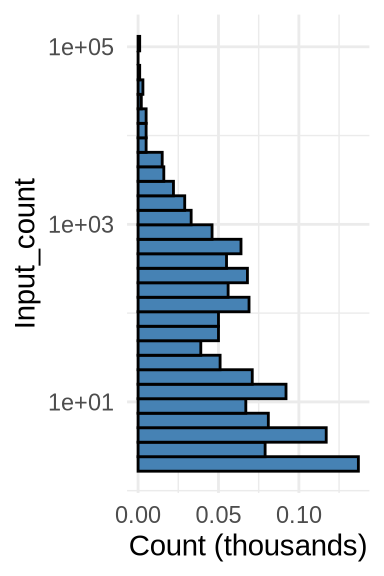

```r
subset_data <- filter_list_25[[3]]$filtered # count >= 2

WT_len <- subset_data |>
  filter(Nham_nt == 0) |>
  pull(sequence_length) |>
  unique() # get WT length

indels <- subset_data |>
  filter(is.na(Nham_nt)) |> # filter for indels
  mutate(indel_length = sequence_length - WT_len) # calculate indel length

read_distribution(indels)
```

## Variant distribution by sequence length

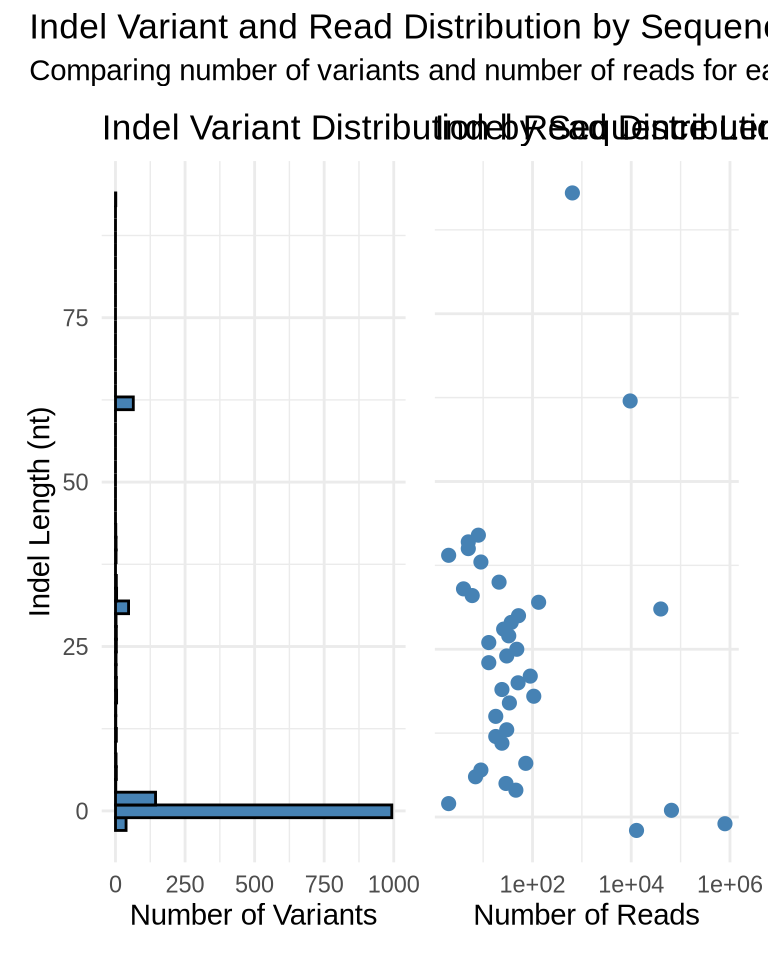

```r
# indel_variant_counts <- summarise(indels, count = n(), .by = indel_length) # summarize to get variant counts at each Nham_nt value

indel_variant_dist <-
  ggplot(indels, aes(y = indel_length)) +
  geom_histogram(bins = 50, fill = "steelblue", colour = "black") +
  # geom_hline(yintercept = 0) +
  # annotate("text",
  #   x = 0.9 * max(indel_variant_counts$count),
  #   y = 0,
  #   label = "WT length",
  #   hjust = 1, vjust = -1) +
  labs(title = "Indel Variant Distribution by Sequence Length",
       x = "Number of Variants",
       y = "Indel Length (nt)") +
  theme_minimal()

# indel read distr
indel_read_counts <- summarise(indels, count = sum(Input_count), .by = indel_length) # summarize to get variant counts at each Nham_nt value

indel_read_dist <-
  ggplot(indel_read_counts, aes(x = count, y = indel_length)) +
  geom_point(size = 2, color = "steelblue") +
  # xlim(0, 5000)
  scale_x_log10() +
  # geom_bar(stat = "identity", fill = "steelblue") +
  labs(title = "Indel Read Distribution by Sequence Length",
       x = "Number of Reads",
       y = "Indel Length (nt)") +
  theme_minimal()

# combine the two plots
indel_variant_dist + indel_read_dist + plot_layout(axes = "collect") +
  plot_annotation(title = "Indel Variant and Read Distribution by Sequence Length",
                  subtitle = "Comparing number of variants and number of reads for each indel length. Note log10 scale on x-axis for read distribution")
```

# Comparing catalysis and leak scores

```r
perc_cat_leak <- subset_data |>
  summarise(frac_cat_leak = 100 * sum(relative_catalysis > relative_leak, na.rm = TRUE) / nrow(subset_data)) |>
  pull(frac_cat_leak)
```

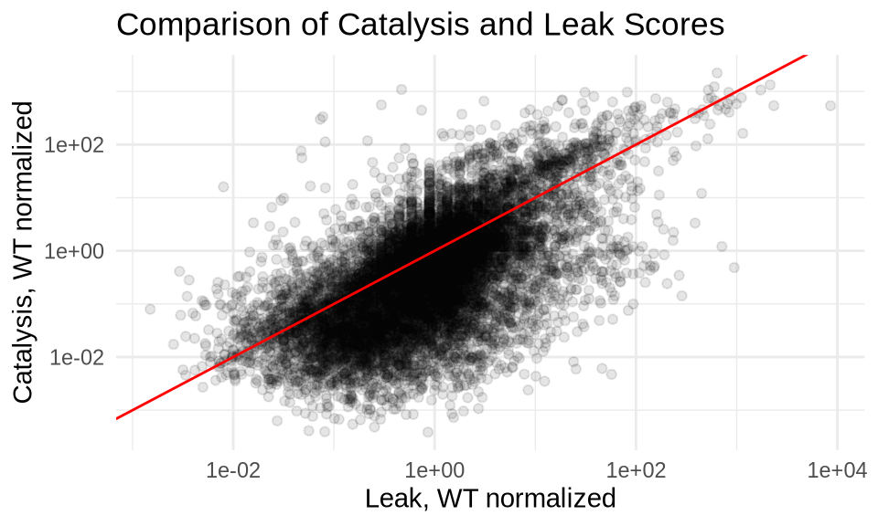

```r
ggplot(subset_data, aes(y = relative_catalysis, x = relative_leak)) +
  geom_point(alpha = 0.1, colour = "black") +
  scale_x_log10() + scale_y_log10() +
  geom_abline(slope = 1, intercept = 0, color = "red") +
  labs(title = "Comparison of Catalysis and Leak Scores",
        y = "Catalysis, WT normalized",
        x = "Leak, WT normalized") +
  theme_minimal()
```

# Mapping contribution to each nucleotide position

## Mapping catalysis scores across the ribozyme sequence

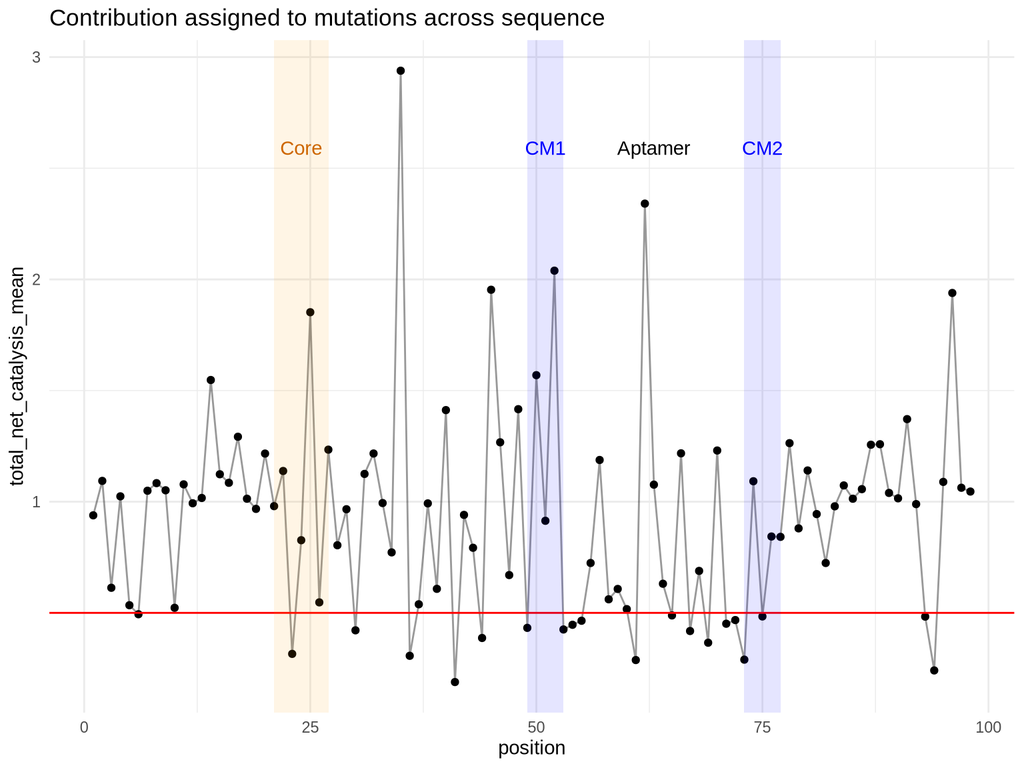

```r
contribution1 <- make_contribution_table(subset_data)

source("functions/1.plotting.R") # temp

# plot total_net catalysis across positions
plot_contribution_across_sequence(contribution1, "total_net_catalysis_mean")
```

## Relative catalysis scores across the ribozyme sequence

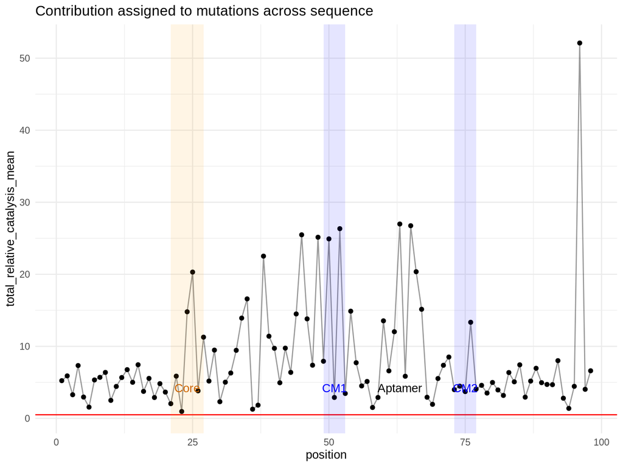

```r
# plot total_relative catalysis across positions
plot_contribution_across_sequence(contribution1, "total_relative_catalysis_mean")
```

## Relative leak scores across the ribozyme sequence

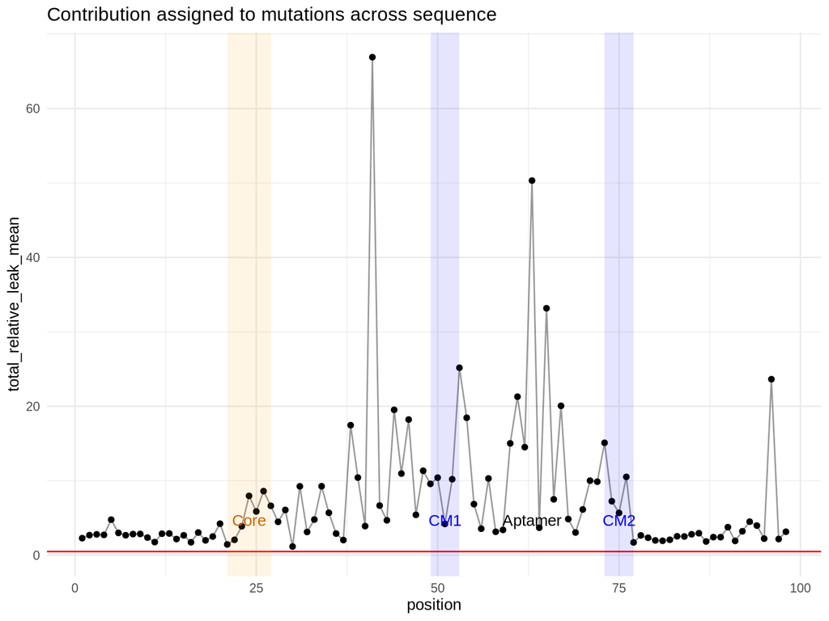

```r
# plot total_relative catalysis across positions
plot_contribution_across_sequence(contribution1, "total_relative_leak_mean")
```

# Selecting variants of interest

Selecting variants that span the distribution of net_catalysis scores for individual testing (with fluorescence)

```r
ranked_catalysis <- subset_data |>
  # filter: no NA and well represented in data and signif selection counts
  filter(if_any(any_of(filter_set_25), \(x) x >= 1000),
    Selection_count >= 10, !is.na(net_catalysis)) |>
  arrange(desc(net_catalysis)) |>
  mutate(rank = row_number())

nrow(ranked_catalysis)
```

```
[1] 1524
```

```r
# WT rank
wt_rank <- filter(ranked_catalysis, Nham_nt == 0) |> pull(rank) |> print()
```

```
[1] 206
```

Rank of the WT variant is 206. Check the distribution of net_catalysis scores for the selection set and the total set.

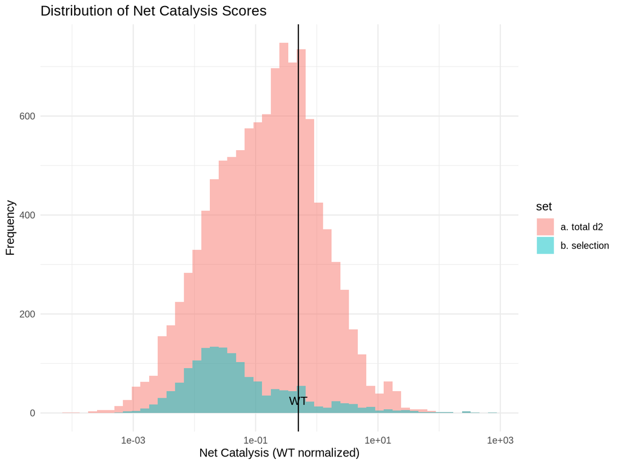

```r
dcomb <- bind_rows(
  ranked_catalysis |> select(net_catalysis) |> mutate(set = "b. selection"),
  subset_data |> select(net_catalysis) |> mutate(set = "a. total d2")
)

ggplot(dcomb, aes(x = net_catalysis, fill = set)) +
  geom_histogram(position = "identity", alpha = 0.5, bins = 50) +
  scale_x_log10() +

  geom_vline(xintercept = 0.5) +
  annotate(geom = "text", x = 0.5, y = 0, label = "WT", vjust = -1) +
  labs(title = "Distribution of Net Catalysis Scores",
       x = "Net Catalysis (WT normalized)",
       y = "Frequency") +
  theme_minimal()
```

The distribution does look distorted but we don’t need it to be representative; as much as pick variants with high coverage.

The table below shows the selected variants of interest for individual testing.

```r
# Select five ranks from the net_catalysis > 1 group and five from the
# remaining distribution, evenly spaced within each group.

selected_ranks <- c( # total 11 variants of interest
  round(seq(1, wt_rank, length.out = 8)), # 7 elements above WT rank
  round(seq(wt_rank, nrow(ranked_catalysis), length.out = 4)) # 3 elements below WT rank
  ) |> unique() # remove duplicate of WT

selected <- ranked_catalysis |>
  filter(rank %in% selected_ranks) |>
  select(nt_seq, rank, net_catalysis, relative_catalysis, relative_leak, Nham_nt, everything())

# save to csv
write_csv(selected, str_c(base_path, "selected_variants_of_interest.csv"))

# Show formatted data
mutate(selected,
  across(where(is.numeric),
    \(x) signif(x, 2) |>
          format(big.mark = ",") )) |>

knitr::kable(caption = "Selected variants of interest for individual testing")
```

Selected variants of interest for individual testing

| nt_seq | rank | net_catalysis | relative_catalysis | relative_leak | Nham_nt | Input_count | Selection_count | Selection_50_count | Selection_75_count | Leak_count | sequence_length | input_freq | selection_freq | selection_50_freq | selection_75_freq | leak_freq | catalysis_score | leak_score | catalysis_score_50 | catalysis_score_75 | relative_catalysis_50 | relative_catalysis_75 |
| --- | --- | --- | --- | --- | --- | --- | --- | --- | --- | --- | --- | --- | --- | --- | --- | --- | --- | --- | --- | --- | --- | --- |
| ttctccttcggtacatccagctgatgagtccaaataggacgaaatacataccagccgaaatgcccttggcaggtgtcctggattccacgaaggagat | 1 | 7.4e+02 | 1.1e+03 | 0.470 | NA | 1.2e+03 | 1.1e+06 | 7.8e+05 | 1.6e+06 | 6.4e+02 | 97 | 1.7e-05 | 1.5e-02 | 1.2e-02 | 1.6e-02 | 6.8e-06 | 9.1e+02 | 0.410 | 690.000 | 940.000 | 830.00 | 1,100.00 |
| ttctccttcggtacatccagctgatgagtcccaaataggacggaatacataccagccgaaaggtccttggcaggtgtcctggattccacgaaggagat | 30 | 1.6e+01 | 1.7e+01 | 0.058 | 2 | 6.2e+02 | 8.6e+03 | 9.4e+03 | 8.2e+03 | 4.1e+01 | 98 | 8.6e-06 | 1.2e-04 | 1.4e-04 | 8.3e-05 | 4.4e-07 | 1.4e+01 | 0.051 | 16.000 | 9.600 | 19.00 | 11.00 |
| ttctccttcggtacatccagctgatgagtcccaaataggacgaaatacataccagccgaaatgcccttggcaggtgtcctggattccacgaaggagat | 60 | 5.1e+00 | 7.6e+00 | 0.490 | 1 | 1.9e+04 | 1.2e+05 | 9.7e+04 | 9.4e+04 | 1.0e+04 | 98 | 2.6e-04 | 1.7e-03 | 1.4e-03 | 9.4e-04 | 1.1e-04 | 6.3e+00 | 0.420 | 5.500 | 3.600 | 6.60 | 4.30 |
| ttctccttcggtacatccagctgatgagtcccacataggacgaaatacataccaaccgataggcccttggcaggtgtcctggattccacgaaggagat | 89 | 3.0e+00 | 3.0e+02 | 97.000 | 3 | 4.2e+03 | 1.0e+06 | 9.0e+05 | 1.7e+06 | 4.5e+05 | 98 | 5.8e-05 | 1.4e-02 | 1.3e-02 | 1.7e-02 | 4.9e-03 | 2.5e+02 | 84.000 | 230.000 | 300.000 | 270.00 | 360.00 |
| ttctccttcggtacatccagctgatgagtcccatatatgacgaagtacataccagccgaaaggcacttggcaggtgtcctggattccacgaaggagat | 120 | 1.9e+00 | 4.7e+02 | 240.000 | 4 | 9.0e+00 | 3.5e+03 | 3.8e+03 | 2.8e+03 | 2.5e+03 | 98 | 1.2e-07 | 4.9e-05 | 5.7e-05 | 2.8e-05 | 2.6e-05 | 3.9e+02 | 210.000 | 450.000 | 230.000 | 540.00 | 270.00 |
| ttctccttcggtacatccagctgatgagtcccaaataggactaaatacataccaaccgaaaggcccttggcaggtgtcctggattccacgaaggagat | 150 | 9.3e-01 | 1.3e+02 | 140.000 | 2 | 3.6e+02 | 3.9e+04 | 5.6e+04 | 4.7e+04 | 5.6e+04 | 98 | 4.9e-06 | 5.4e-04 | 8.3e-04 | 4.7e-04 | 6.0e-04 | 1.1e+02 | 120.000 | 170.000 | 96.000 | 200.00 | 110.00 |
| ttctccttcggtacatccagctgacgagtcccaaataggacgaaatacataccagccgaaatgcccttggcaggtgtcctggattccacgaaggagat | 180 | 6.3e-01 | 3.3e+00 | 4.100 | 2 | 4.8e+02 | 1.3e+03 | 3.4e+03 | 3.5e+03 | 2.2e+03 | 98 | 6.7e-06 | 1.8e-05 | 5.0e-05 | 3.5e-05 | 2.4e-05 | 2.7e+00 | 3.600 | 7.400 | 5.200 | 8.90 | 6.20 |
| ttctccttcggtacatccagctgatgagtcccaaataggacgaaatacataccagccgaaaggcccttggcaggtgtcctggattccacgaaggagat | 210 | 5.0e-01 | 1.0e+00 | 1.000 | 0 | 5.0e+07 | 4.1e+07 | 3.3e+07 | 5.1e+07 | 5.6e+07 | 98 | 6.9e-01 | 5.8e-01 | 4.8e-01 | 5.1e-01 | 6.0e-01 | 8.4e-01 | 0.870 | 0.700 | 0.730 | 0.83 | 0.88 |
| ttctccttcggtacatccagctgatgagtcccaaataggacgaaatacataccagcccaaaggcccttggcaggtgtcctggattccacgaaggagat | 640 | 4.7e-02 | 9.5e-02 | 1.000 | 1 | 1.6e+04 | 1.2e+03 | 2.0e+03 | 9.1e+02 | 1.8e+04 | 98 | 2.2e-04 | 1.7e-05 | 2.9e-05 | 9.1e-06 | 1.9e-04 | 7.9e-02 | 0.880 | 0.130 | 0.042 | 0.16 | 0.05 |
| ttctccttcggtacatccagctgacgagtcccaaataggacgaaatacataccagccgaaaggcccttggcacgtgtcctggattccacgaaggagat | 1,100 | 1.6e-02 | 2.1e-01 | 13.000 | 2 | 1.2e+03 | 2.1e+02 | 1.1e+02 | 1.4e+02 | 1.7e+04 | 98 | 1.6e-05 | 2.9e-06 | 1.6e-06 | 1.4e-06 | 1.8e-04 | 1.8e-01 | 11.000 | 0.098 | 0.084 | 0.12 | 0.10 |
| ttctccttcggtacatccagctgatgagtcccaaacaggacgaaatacataccagccgaaaggcccttggcaagtgtcctggattccacgaaggagat | 1,500 | 5.9e-04 | 2.2e-03 | 2.700 | 2 | 5.4e+03 | 1.0e+01 | 0.0e+00 | 0.0e+00 | 1.7e+04 | 98 | 7.5e-05 | 1.4e-07 | 0.0e+00 | 0.0e+00 | 1.8e-04 | 1.9e-03 | 2.400 | 0.000 | 0.000 | 0.00 | 0.00 |

## Send thresholded data to Dylan

Remove insertions and deletions, and save separate files for each threshold. This will be used for individual testing of variants.

```r
# create path if it doesn't exist
dylan_files <- str_c(base_path, "dylan_files/")
if (!dir.exists(dylan_files)) {
  dir.create(dylan_files, recursive = TRUE)
}

total_variants <- nrow(data)

map2(filter_list_25, thresholds,
  \(x, t) {
    filtered_data <- x$filtered |>
      filter(!is.na(Nham_nt)) # remove indels

  # report the percentage of total variants that pass the threshold
  cat("threshold >= ", t, ": ", format(nrow(filtered_data)/total_variants * 100, digits = 2), " % of total variants\n")
  cat("\t Retains: ", format(nrow(filtered_data), big.mark = ","), " variants\n\n")

    write_csv(filtered_data, str_c(dylan_files, "filtered_threshold_", t, ".csv"))
  })
```

```
threshold >=  0 :  75  % of total variants
     Retains:  404,147  variants

threshold >=  1 :  2.6  % of total variants
     Retains:  13,834  variants

threshold >=  2 :  1.8  % of total variants
     Retains:  9,652  variants

threshold >=  5 :  1.1  % of total variants
     Retains:  5,804  variants

threshold >=  10 :  0.71  % of total variants
     Retains:  3,849  variants

threshold >=  100 :  0.16  % of total variants
     Retains:  881  variants
```

[output not shown]

[output cut: 76 more lines]

[output not shown]